# Consumer’s Preference Analysis on Used EV

Huajie Zhu, Mohammad Khan, Ruchi Saraf, Joey Shonubi, Lujin Zhao

December 12, 2021

# Abstract

In this study, we were interested in finding out the factors that influenced people’s preferences or aversion for electric vehicles. With the used auto-vehicle market significantly outweighing the new vehicle market, our focus was directed towards used electric vehicles and the various conditions that has limited its adoption. Our goal was to identify how consumers’ preferences change with varying attributes such as price, mileage, brand, model year, range, warranty and power/energy sources. Using these attributes, we carried out a survey providing consumers with different options in order to gain insights into how their choices changed with each attribute. A total of *170* respondents were considered for the survey in order to provide a comprehensive/balanced data source. Ultimately, we discovered that consumers prefer to have free charging stations from the dealer. Participants who did not possess EV preferred are less sensitive to charging station promotion and Finally, price and range are the main driving force for used EV demand.

# Introduction

The Transportation sector is the biggest source of Greenhouse Gas emissions in the United States and besides reducing the number of fuel engines by promoting public transportation, pushing the adoption of Electric Vehicles is a great way to cut tail-pipe emission

While the adoption of Electric vehicles seems like a simple response and the EV market has been booming since 2017, the reality remains that market size of electric vehicles is still small despite the government incentives and environmental benefits. To paint a clearer picture, the used auto market is much bigger than the new auto market. However, for electric vehicles, the used EV market is only just starting to find its feet.

This market situation is also described by Rogers’ Technology Adoption Theorem. Rogers (2003) describes the adoption categories in five parts according to his technology diffusion theory namely Innovators, Early Adopters, Early Majority, Late Majority and Laggards. The distribution of these categories follows a normal distribution with people of high socioeconomic status adopting new technology earlier than the vast majority of early and late users which make two-thirds of the total members.Given the side of EV market today, we can assume assume that majority of potential buyers are waiting for core attributes such as lower prices or more reliable technology . This makes the exploration of the used EV market critical to the adoption of this technology.

!

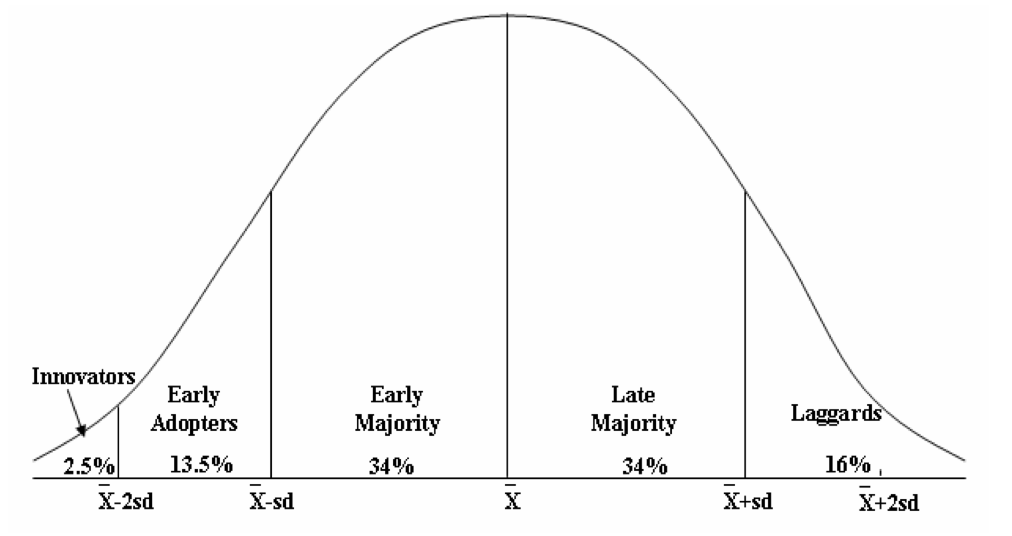

The share of the EV second-hand market in the second-hand car market is slowly rising with the sales of electrified vehicles jumping from 4.8% of the market in the first quarter of 2020 to 7.8% in the same period of 2021. Used electric vehicle marketing is gaining more attention as people are realizing its benefits in comparison to the cars on gas. The goal of this project is to explore the factors that influence the choices of car buyers especially with those inclined towards electric vehicles and the used vehicle market. Our focus is to create and analyze data sets to give facts and help individuals make decisions.

Currently many incentives are given by the public sector and private sector on used and new EVs to reduce carbon emission. One of the private sector companies pays its employees $2000 if they opt in to buy an electric vehicle if they have worked for the company for at least one year.

Our main focus is to look into used EV vs the normal gas car and compare and capture insights by doing a survey of what is the thought process of people looking to buy cars.

Some of the studies have shown that if some sort of incentive or rebate is given, it really has an effect on the customer’s decisions , especially if the customer is considered between a low to average income household.(Legislators propose $2,500 federal tax credit ) One of the things we can’t quantify is the features coming in with used EV so that’s one area we can’t incentivize the customer.

Looking into the behavior of our stakeholders i.e potential used EV buyers would give us a comprehensive insight on how generally used EV is perceived by the general public and what this market would be like in the near future.

Out of scope is the market for new EV for this current project since we won’t be asking our stakeholder anything related to the new EV in the survey. The reason for this is to just focus on the used EV market vs the gas cars. Looking into new EVs won’t be beneficial since there are a lot of options on how a customer can customize their cars and in comparison it’s not possible to do that in used EVs.

# Survey Design

There are two eligibility requirements in our design choices. The first is whether the survey subject is over 18 years old. The second requirement is to finish understanding the above information. Our project is about the purchase of used vehicles, where people over 18 years old have spending power, and by reading the information, the respondent has a basic idea of the direction of the survey.

We only collect two pieces of information that interviewees live in the DMV area or not and the current zip code at the beginning. These two pieces of information were collected to determine whether the interviewees lived in a DMV area. Our survey was limited to the DMV area. Our interview population was also limited to people living in the DMV area. We also asked interviewees if they had any intention of purchasing a vehicle in the next six months. If yes it would meet our interview requirements because the price of the vehicle is time sensitive.

At the end of the survey, we will ask six more questions, if the interviewer finished our survey. We will use it for analyzing our survey data. Five questions that “In what year were you born?”, “How many cars are currently present in your household?”, “ Do you currently or have you owned an electric vehicle?” , “What is your current gender identity?”, “I identify my race as” , and “What is your annual household income (from all sources) before taxes and other deductions from pay?”. If the interviewees are not part of our interview scope, they will not see these questions.

We provided educational material about the vehicle’s functions, such as “Price”, “Mileage”, “Model Year”, “Brand”, “Range”, “Warranty”, “Charging Station”, and “Fast Recharge”. The “Price” refers to the price to buy this car. The “Mileage” that it refers to is how much the car has been driven. The “Model Year” that it is the year when the car was manufactured. The “Brand” shows the brand of this car. The “Range” that it’s the number of miles a car can drive in one complete charge. The “Warranty” is whether the car comes with a warranty or not. The “Charging Station” is whether the dealer offers a free home charging port when you buy the car. The “Fast Recharge” that the car can be charged faster than its normal charging time

### Changes to the Survey

We noticed that our doe contains some unreasonable situations such as a 1 year used car with 50k miles and 5 year car with 5k miles. This kind of extreme cases need to be fixed and we will make sure the mileage are within a reasonable range according to the model year. Besides that, we also increased the minimum price and mileage to $10,000 and 5,000 from $5,000 and 1,000 respectively. They are now both increasing in a 5,000 increment instead of 1,000 increment. In this way, we could significantly reduce the total number of doe under a full factorial design. We are also planning to increase the minimum EV range from (100,250) to (200,400) interval, which is much reasonable representation of current EVs’ specification.

We also noticed the chart we have is very misleading for some participants. Showing a Tesla image and put only 200 miles in the range attribute is inconsistent for participants who are familiar with EVs. To achieve the generality of the estimation result, we will exclude the image and only present attributes in text. To account for the endogeneity of our model, we will ask the participants to assume all cars are a black sedan in a good condition.

However, we understand the limitation in ways to distribute our survey and since we are having a very specific geographic requirement on out participants, we will not get sufficient observations suggested by the power analysis. What we will do is increase the number of questions that each participant have to answer so we could get the error bar narrower.

### Final Survey Design

| Attributes | Range/Level |
| --- | --- |
| Price | $ 10,000 to $50,000 |
| Mileage | 10,000 to 70,000 |
| Model Year | 2014 to 2020 |
| Range | 200 to 400 |
| Fuel Economy | 15 to 35 |
| Powertrain | Gas/Electric |
| Warranty | Yes/No |
| Charging Station | No Promotion/Discounted/Free |

Sample Survey is listed below:

**Option 1**

**Price**: $ 10,000 **Mileage**: 24,000 **ModelYear**: 2017 **powertrain**: Electric **range**: 400 **MPG**: NA **Warranty**: Yes **Charging Station Promotion**: Free

**Option 2**

**Price**: $ 30,000 **Mileage**: 14,000 **ModelYear**: 2019 **powertrain**: Gas **range**: NA **MPG**: 25 **Warranty**: No **Charging Station Promotion**: NA

**Option 3**

**Price**: $ 30,000 **Mileage**: 14,000 **ModelYear**: 2019 **powertrain**: Electric **range**: 300 **MPG**: NA **Warranty**: No **Charging Station Promotion**: No Promotion

# Data Analysis

The data was collected from late November to early December 2021. At the beginning we have 335 participants took the survey and 213 eligible results were received. The survey results were then went through a data cleaning process to drop bad responses. The criteria we used for this process are:

1. Did the participant finish all questions?
2. Did the participant choose same options across all eight questions?

Since our survey questions are randomly picked for each participant, it is unlikely to choose same options for all 8 questions. This kind of behavior make us believe that the participant was not paying attention at all to our survey.

3. Did the participant answer questions too fast?

Participant could also randomly clicking through our survey to avoid being easily detected by the previous criteria. To identify such bad responses, we will use time spent during the survey to filter them out.

To determine whether participants were going to fast, we first calculated the total time spend on survey for each participant. Then we get the distribution of total time and identify a reasonable cut-off point. Participants who spend less time than the cut-off time will be identified and dropped.

To determine the cut-off point, our group members randomly clicking through the survey and record the time spent. After multiple tries, we found that it took about 2.5 minutes to finish if you are not paying attention to our questions at all. To include participants that are slightly higher than 2.5 minutes, we decided to use the 10% quantile, which is 2.8 minutes, as the cut-off point.

The first step drops 21, the second step drops 3 and the third step drops 19 participants. In total 43 participants were dropped, so out final dataset contains 170 participants. The summary statistics is shown in the following table:

```r
#Summary Statistics
choiceData <- read_csv(here("data","choiceData.csv"))
summary_stat <- choiceData %>%
  mutate(age=2021-yearOfBirth,
         gender=if_else(gender=="male",1,0),
         ev=abs(ev-2),
         dc=abs(dc_resident-2),
         carbuyer=abs(car_buyer-2)) %>%
  distinct(respID,.keep_all=TRUE) %>%
  select(age,gender,ev,dc,carbuyer) %>%
  summarise_each(funs(mean=mean,
                      sd=sd,
                      min=min,
                      max=max))
df <- summary_stat %>%
  gather(stat,val) %>%
  separate(stat, into = c("var", "stat"), sep = "_") %>%
  spread(stat, val) %>%
  select(var,mean, sd, min, max) %>%
  mutate(var=fct_recode(var,
                        "dc resident"="dc",
                        "car_buyer"="carbuyer",
                        "has_ev"="ev"))

df %>%
  kbl() %>%
  kable_styling()
```

| var | mean | sd | min | max |
| --- | --- | --- | --- | --- |
| age | 34.3647059 | 13.7478106 | 18 | 73 |
| car_buyer | 0.3411765 | 0.4755051 | 0 | 1 |
| dc resident | 0.3823529 | 0.4873977 | 0 | 1 |
| has_ev | 0.0588235 | 0.2359892 | 0 | 1 |
| gender | 0.4411765 | 0.4979946 | 0 | 1 |

### Modeling

The utility mode is constructed as the following.

$U_{ij}=\beta_1x^{price}_j+\beta_2x^{fuel\_econ}_j+\beta_3x^{model\_year}_j+\beta_4x^{range}_j+\beta_5x^{mileage}_j+\beta_6\delta^{gas}_j+\beta_7\delta^{have\_warranty}_j+\beta_8\delta^{free\_cs}_j+\beta_9\delta^{discounted\_cs}_j+\epsilon_{ij}$

where $\delta^{gas}$, $\delta^{have\_warranty}$, $\delta^{free\_cs}$ and $\delta^{discounted\_cs}$ are dummies for being gas car, have warranty, dealer provide free charging station and dealer provide discounted price for charging station respectively.

We have estimated a multinomial, mixed logit and create a subgroup based on whether participants have owned an EV before. The preference space results are shown in the following table

```r
source("modeling.R")

mxl_result <- mxl_result %>%
  filter(str_detect(vars,"sigma",negate = TRUE)) %>%
  mutate(vars=fct_recode(vars,
    "price"="price_mu",
    "Mileage"="Mileage_mu"
  ))

results <- cbind(mnl_result,mxl_result[,2:3],sub_result[,2:3])
names(results) <- c("Vars","MNL", "MNL sd","MXL", "MXL sd","Has EV", "Has EV sd")

results %>%
  kbl() %>%
  kable_styling()
```

| Vars | MNL | MNL sd | MXL | MXL sd | Has EV | Has EV sd |
| --- | --- | --- | --- | --- | --- | --- |
| price | -0.08 | 0.004 | -0.11 | 0.008 | -0.09 | 0.019 |
| fuelEconomy | 0.05 | 0.008 | 0.06 | 0.010 | 0.07 | 0.042 |
| modelyear | -0.10 | 0.026 | -0.13 | 0.030 | -0.35 | 0.134 |
| powertrain_Gas | -0.69 | 0.339 | -0.59 | 0.381 | 0.57 | 1.609 |
| Warranty | 0.54 | 0.080 | 0.63 | 0.092 | 1.05 | 0.392 |
| range | 0.00 | 0.001 | 0.01 | 0.001 | 0.01 | 0.004 |
| Mileage | -0.02 | 0.003 | -0.03 | 0.004 | -0.03 | 0.014 |
| ChargingStation_Free | 0.21 | 0.133 | 0.21 | 0.151 | 0.99 | 0.628 |
| ChargingStation_Discounted | -0.05 | 0.135 | 0.02 | 0.152 | 0.41 | 0.653 |

# Results

### Willingness to Pay

WTP Simulation

The WTP model is computed and estimated in Preference Space and WTP Space. The data frames have been created for each WTP variable and then plotted. For the purpose of analysis, the baseline for ‘fuel economy’ is set to 15, the ‘model year’ is computed as how old the car is when compared to the model year 2021, the ‘price’ is scaled down to thousand dollars, and the ‘mileage’ is also scaled down by 1000. The Willingness to pay per thousand dollars for the attributes - “Range”, “Mileage”,”Fuel Economy”, “Powertrain Gas”, “Warranty”, “Model Year” “Free Charging Station” and “Discounted Charging Station” as follows,

!

[figure not shown]

To understand the Willingness to Pay per Feature, a mixed logit model is constructed. After cleaning out the data, the survey comprises 170 participants for analysis of WTP. From the chart, it is observed that the participants are willing to pay more for ‘Warranty’ and for ‘Free Charging Station. The error margin for WTP for Free Charging Station is so large, that the data cannot be relied upon for this attribute, the same goes for Charging Station being Discounted. People are willing to pay a few thousand dollars for an improved ‘Fuel Economy’. For attributes such as ‘Range’ and ‘Mileage’, it seems that the participants do not want to pay more for an improved ‘Range’ or ‘Mileage’. The graph demonstrates the negative WTP for ‘Model Year’ and ‘Gas’ cars, which implies that they want cheaper versions of these attributes. The error margin for “powertrain_Gas” indicates that this data is not very reliable due to heterogeneity present in the survey results.

!

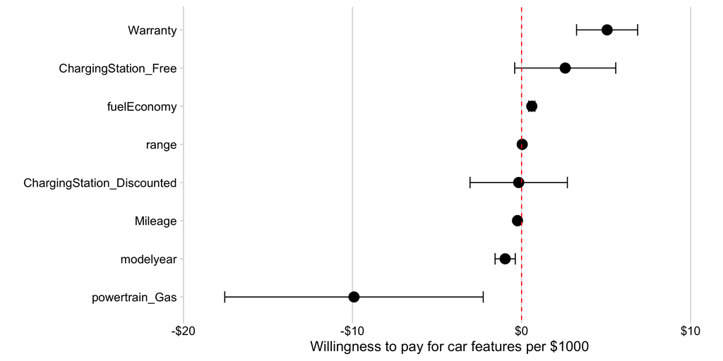

To account for these attributes- “Charging Station Discounted” and “Powertrain Gas” the data has been divided into two groups based on the information provided by the participants, on the basis of the fact that they have an Electric Vehicle or not. After filtering out the data, from the 170 participants, 160 of them don’t have an ‘Electric Vehicle’ and 10 of them have an Electrical Vehicle. The Willingness to Pay distribution for these subgroups is as follows,

!

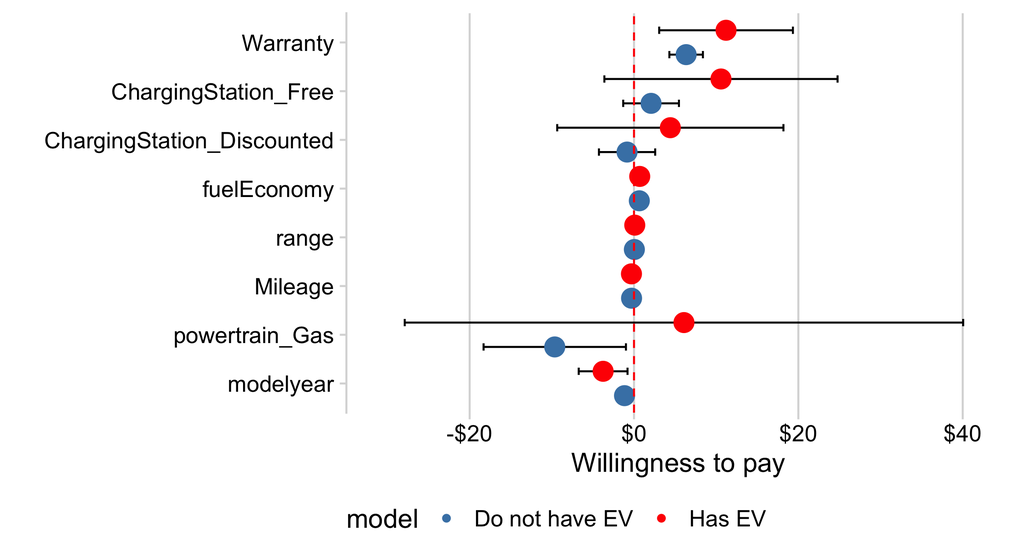

### Market Share Simulation

Simulation analysis；

We make six groups and analysis them that gas cars, EVs, and EVs with the free charging station. Every type of car has two conditions, “good” or “fair”, so total have six different conditions that “good” gas car, “good” EV, “good” EV with free charging station, “fair” gas car, “fair” EV, and “fair” EV with a free charging station. I will next find out the market share relationship with each other by controlling for variables, and variables are model year, range, price, warranty, and mileage.

First, we are comparing “fair” gas cars, “fair” EV, and “fair” EVs with free charging stations. For a “fair” gas car, the set up that model year are 5, the range is 0, price is $20 thousand, the fuel economy is 5, with the warranty, and 40 thousand mileages. For a “good” gas car, the set up that model year are 3, the range is 0, price is $20 thousand, the fuel economy is 10, with the warranty, and 30 thousand mileages. For “fair” EV, the set up that the model year is 3, range are 300, price is $25 thousand, the fuel economy is 0, with the warranty, and 30 thousand mileages. For “good” EV, the set up that the model year is 2, range are 400, price is $25 thousand, the fuel economy is 0, with the warranty, and 20 thousand mileages. For the “fair” EV with free charging station, the set up that the model year is 3, range are 300, price is $25 thousand, the fuel economy is 0, without the warranty, and 30 thousand mileages. For the “good” EV with free charging station, the set up that the model year is 2, range are 400, price is $25 thousand, the fuel economy is 0, with the warranty, and 20 thousand mileages.

!

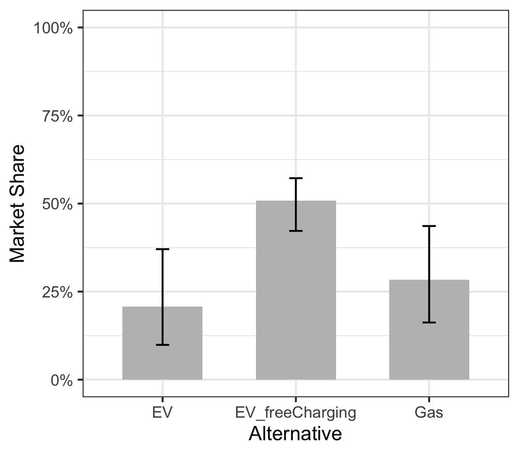

Then, we obtained the other five plots of data by variables. Plot 1 and plot 4 are the control groups, the gas car change to “good” in plot 4. When a gas car is “good”, but EV and EV with free charging stations are still “fair”, the gas car’s market share will be more than EV and EVFreeCS.

!

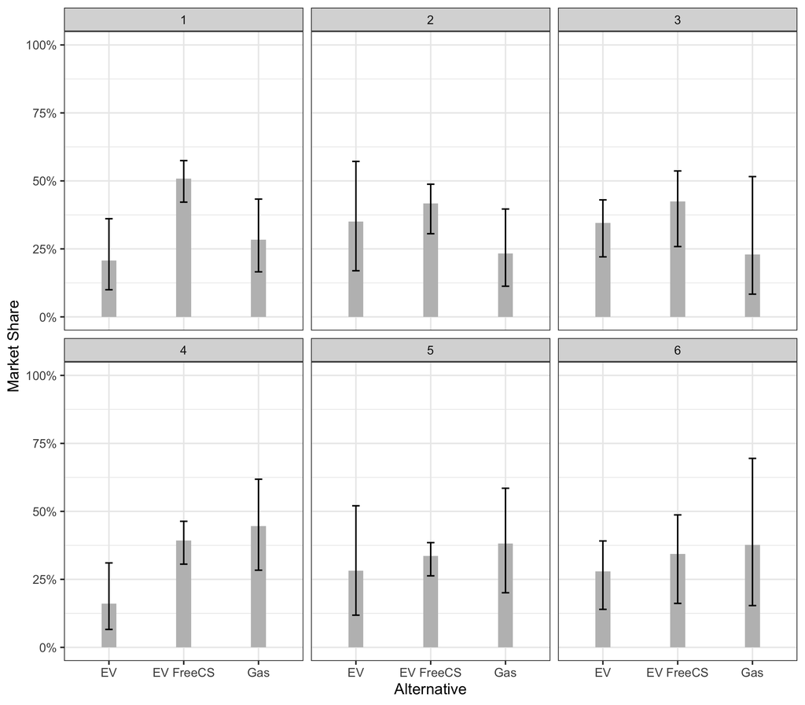

Plot 2 and plot 5 are the control groups. EV change to “good” in plot 2. Gas car and EV are all “good” in plot 5. We find “good” EV’s market share is still not better than “fair” EVFreeCS, but more than “fair” gas car. But when gas cars change to “good” in plot 5, the market share change to biggest, and “fair” EVFreeCS’s market share is more than “good” EV right now.

Plot 3 and plot 6 are the control groups. EV and EVFreeCS change to “good” in plot 3, but gas cars are still “fair”. We find EV and EVFreeCS’s market share are all more than gas cars, and EVFreeCS’s market share is the highest. But when we change all three types of vehicles to “good”, we find the gas car has the highest market share, EV still the lowest.

### Sensitivity Analysis

Sensitivity analysis in our project is used to determine how independent variables have an effect on dependent variables. Different values, scenarios were discussed to see which variables would have the highest impact on the sale of used EV. Some of the baseline scenarios used are as under:

```r
baseline %>%
  kbl() %>%
  kable_styling()
```

| altID | obsID | modelyear | range | price | fuelEconomy | Warranty | Mileage | powertrain_Gas | ChargingStation_Free | ChargingStation_Discounted |
| --- | --- | --- | --- | --- | --- | --- | --- | --- | --- | --- |
| 1 | 1 | 1 | 0 | 15 | 15 | 1 | 6 | 1 | 0 | 0 |
| 2 | 1 | 2 | 200 | 25 | 0 | 0 | 10 | 0 | 1 | 0 |
| 3 | 1 | 3 | 0 | 21 | 20 | 1 | 30 | 1 | 0 | 0 |

In the baseline scenario, we have three different options:

1. 2020 Gas car selling at $15,000 with a warranty. 15 mpg and 6,000 mile driven
2. 2019 Electric car selling at $25,000 without a warranty. 200 miles of battery ranges, 10,000 mile driven and free charging station from the dealer.
3. 2018 Gas car selling at $21,000 with a warranty. 20 mpg and 30,000 mile driven

!

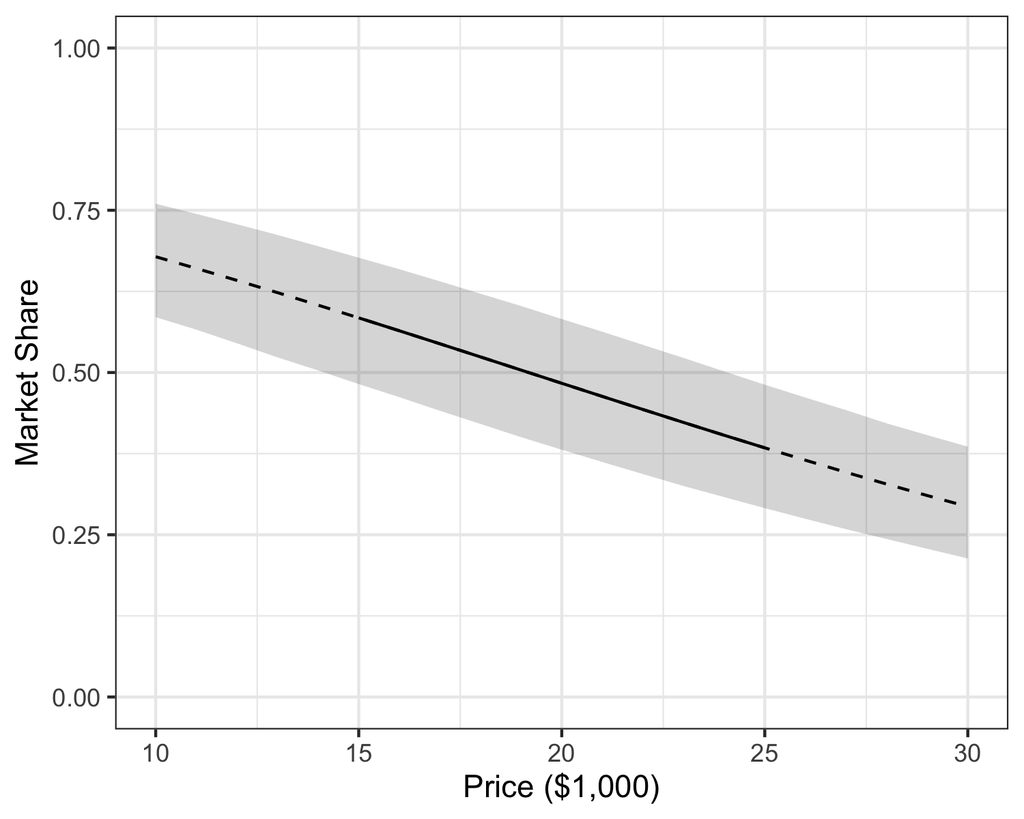

For the high/low scenarios, we change the attributes based on option 2. In the High scenario, we are assuming the EV is having 20% less price and mileage, 20% more range and 2 years newer than the baseline model. In the Low scenario, we are assuming the EV is having 20% more price and mileage, 20% less range and 2 years older than the baseline model.

!

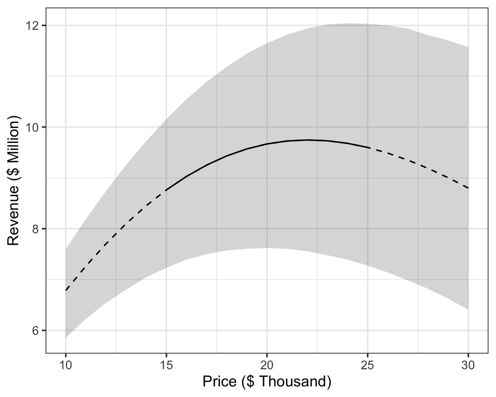

!

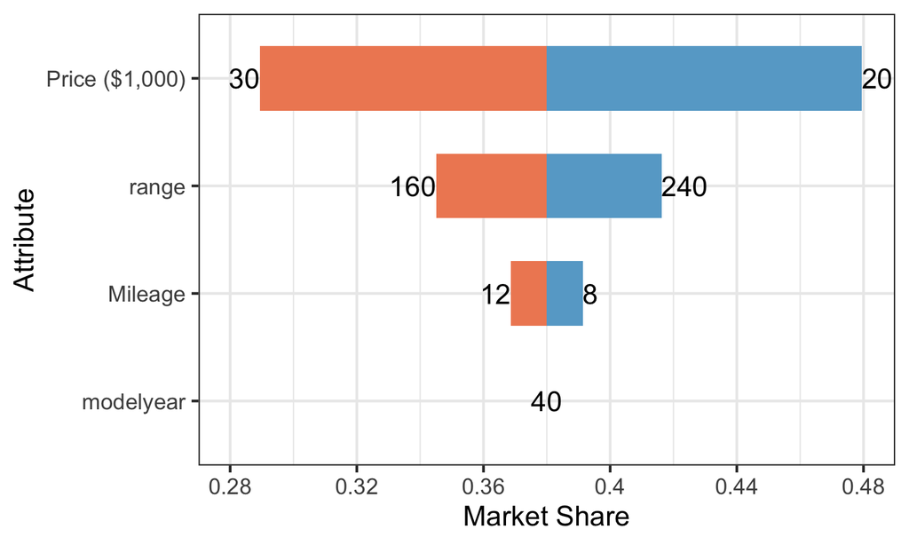

In conclusion we confirmed that buyers are sensitive to price and range of the EV and not very sensitive to mileage and model year of the car. Adjusting the price to a correct level could boost the sale significantly.

# Final Recommendations and Conclusions

The main unknown factor now is how the brand and other attributes that are not included here could affect consumer’s preference. In this study, we are assuming EV and gas car are the same besides attributes shown above. In reality, the differences between EVs could be much bigger than gas car. Few manufactures and models are competing in EV market and little similarity exists between thsoe models. We do not know if consumers will have same choice behavior toward Tesla and Honda or not. As a result, current analysis can only tell the dealer, for a EV that really similar to Gas car, how consumers’ preference will be.

# Limitations

Currently, we only have 170 participants, which is lead to the large variance our estimation has. Besides that, we do not have important car attributes such as brand and technology iteration in our survey. Those attributes could have significant impact on consumers’ perspective toward EV appriciation. Right now in this analysis, we assum all options are the same except attributes shown. In the reality, however, preference toward brand could determine how consumers value those attributes.

We also need a more efficient way to include attributes in this survey. For a a used car, there are more attributes than what we are showing here. Right now in the survey, we already have too many information showing to our participants which could take a lot of efforts for them to process. In our pilot trail, it took us more than five minutes to finish all eight questions if we are evaluating every option carefully. However in our survey result, 50% participants take far less time to finish the survey. Simply adding more attributes to the list will only cause participants unable to focus and making inconsistent choices.

# Appendix

## Welcome to our survey!

**Used Electric Vehicle Study**

Welcome

You are invited to take part in a research study being conducted by students in Engineering Management and Systems Engineering at The George Washington University.

This survey would help us to learn extensively about user preferences between electric vehicles and possibly impact the future of the vehicle industry.

Please read this form and ask us any questions that will help you decide if you want to be in the study. Taking part is completely voluntary and even if you decide you want to, you can quit at any time.

## Content form

You are being invited to participate in a research study on the used electric vehicle market. This study is being done by Huajei Zhu, Joye Shonubi , Lujin Zhao, Mohammed Khan and Ruchi Saraf who are students of The George Washington University.

The purpose of this research study is to identify consumers’ preferences on Used Electric Vehicles and make comparisons with traditional gas cars. If you agree to the terms and participate in this study , you will be asked to complete an online survey.

By clicking “I agree” below , you are indicating that you are at least 18 years old, have read and understood this consent form and agree to participate in this research study

- I agree to the terms and conditions
- I disagree

## Eligibility questions for screening our ineligible respondents

Are you want to buy a vehicle?

- Yes, I want to buy a gas car
- Yes, I want to buy a EV
- No

## Great work!

### Price

refers to the price to buy this car

### Mileage

It refers to how much the car has been driven

### Model Year

It is the year when car was manufactured

### Brand

Shows the brand of this car

### Range

Its the number of miles a car can drive in one complete charge.

### Warranty

Is whether the car comes with a warranty or not

### Charging Station

Is whether dealer offers a free home charging port when you buy the car

### Fast Recharge

This entails that the car can be charged faster than its normal charging time

## Practice Question

For example, if these were the only apples available, which would you choose?

**Option 1**

**Price**: $ 10,000 **Mileage**: 24,000 **ModelYear**: 2017 **powertrain**: Electric **range**: 400 **MPG**: NA **Warranty**: Yes **Charging Station Promotion**: Free

**Option 2**

**Price**: $ 30,000 **Mileage**: 14,000 **ModelYear**: 2019 **powertrain**: Gas **range**: NA **MPG**: 25 **Warranty**: No **Charging Station Promotion**: NA

**Option 3**

**Price**: $ 30,000 **Mileage**: 14,000 **ModelYear**: 2019 **powertrain**: Electric **range**: 300 **MPG**: NA **Warranty**: No **Charging Station Promotion**: No Promotion

## Great work!

We will now show you 8 sets of choice questions starting on the next page.

(1 of 8) If these were your only options, which would you choose?

**Option 1**

**Price**: $45000 **Mileage**: 15000 **ModelYear**: 2018 **Powertrain**: Gas **Range**: 0 **MPG**: 30 **Warranty**: No **Charging Station Promotion**: No Promotion

**Option 2**

**Price**: $45000 **Mileage**: 52000 **ModelYear**: 2014 **Powertrain**: Electric **Range**: 300 **MPG**: 0 **Warranty**: Yes **Charging Station Promotion**: No Promotion

**Option 3**

**Price**: $25000 **Mileage**: 22000 **ModelYear**: 2014 **Powertrain**: Electric **Range**: 400 **MPG**: 0 **Warranty**: No **Charging Station Promotion**: Free

## Nice job!

We’re almost done! We’d just like to ask just a few more questions about you which we will only use for analyzing our survey data.

1. In what year were you born?

(Drop down menu including `Prefer not to say` and years `1920` - `2003`)

2. How many cars are currently present in your household?

(Drop down menu including `Prefer not to say` and years `0` - `5`)

3. Do you currently or have you owned an electric vehicle?
- Yes
- No
4. What is your current gender identity? Different identity (please state):
- Male
- Female
5. I identify my race as (select all that apply): Different identity (please state):
- Asian
- African American or Black
- White (Not of Hispanic or Latino origin)
- Hispanic or Latino
- American Indian or Alaska Native
- Native Hawaiian or Pacific Islander
- Prefer not to say
6. What is your annual household income (from all sources) before taxes and other deductions from pay?
- Less than $10,000
- $10,000 - $14,999
- $15,000 - $24,999
- $25,000 - $34,999
- $35,000 - $49,999
- $50,000 - $74,999
- $75,000 - $99,999
- $100,000 - $149,999
- $150,000 - $199,999
- $200,000 or more
- Prefer not to say

Please let us know if you have any other thoughts or feedback on this survey.

Your feedback will help us make future improvements :)

(Open text response)

Finish